# DATA606_Final_Project_Proposal

Matheesha Thambeliyagodage

May 4, 2017

### Research question

- Is there any correlation between the # of Airports and Human Population in the states, counties in USA

### What are the cases, and how many are there?

- In he data I identified following types of airports availale in the USA.
  - Heliport
  - Small_airport
  - Closed
  - Seaplane_base
  - Balloonport
  - Medium_airport
  - Large_airport
- US population live around these airports.
- Identifying the distribution around them is the case.

### Describe the method of data collection:

- For this project I am using the data feeds from the following two sites

  1. http://ourairports.com/data.

  2. https://www2.census.gov/programs-surveys/popest/datasets.
- In these web sites I found important, accurate and up-to-date data information
- I made direct downloads from the .csv files into the data frames.
- Using the R package **dplyr** hope to do staging of the data.

### What type of study is this:

- Thisis a Observational study, because from the existing data I am trying to identify the correlation.

### Data Source:

1.http://ourairports.com/data. - This site has most updated data about airports in the world. I do filter only the airports in USA

2.https://www2.census.gov/programs-surveys/popest/datasets. - USA Census web site

### Response:

- The response variable is number of airports and is numerical.

### Explanatory:

- The population in the area is the Explanatory and it is also numerical.

### Relevant summary statistics

```r
#load ourairports data from .scv files
#ourairports

#Loading airports.csv
airports_df <- read.csv("https://raw.githubusercontent.com/mathsanu/CUNY_MSDA/master/DATA606/FinalDataProject/Data/airports.csv", header=TRUE)
#airports_df <- read.csv("http://ourairports.com/data/airports.csv", header=TRUE)

#Loading countries.csv
countries_df <- read.csv("https://raw.githubusercontent.com/mathsanu/CUNY_MSDA/master/DATA606/FinalDataProject/Data/countries.csv", header=TRUE)
#airports_df <- read.csv("http://ourairports.com/data//countries.csv", header=TRUE)


#Loading regions.csv
regions_df <- read.csv("https://raw.githubusercontent.com/mathsanu/CUNY_MSDA/master/DATA606/FinalDataProject/Data/regions.csv", header=TRUE)
#airports_df <- read.csv("http://ourairports.com/data//regions.csv", header=TRUE)

#Loading runwayss.csv
runways_df <- read.csv("https://raw.githubusercontent.com/mathsanu/CUNY_MSDA/master/DATA606/FinalDataProject/Data/runways.csv", header=TRUE)
#airports_df <- read.csv("http://ourairports.com/data/runways.csv", header=TRUE)

#Loading US Populations data
Popult_df <- read.csv("https://www2.census.gov/programs-surveys/popest/datasets/2010-2016/national/totals/nst-est2016-popchg2010_2016.csv", header=TRUE)

head(airports_df)
```

```
##       id ident          type                               name
## 1   6523   00A      heliport                  Total Rf Heliport
## 2   6524  00AK small_airport                       Lowell Field
## 3   6525  00AL small_airport                       Epps Airpark
## 4   6526  00AR        closed Newport Hospital & Clinic Heliport
## 5 322127  00AS small_airport                     Fulton Airport
## 6   6527  00AZ small_airport                     Cordes Airport
##   latitude_deg longitude_deg elevation_ft continent iso_country iso_region
## 1      40.0708     -74.93360           11      <NA>          US      US-PA
## 2      59.9492    -151.69600          450      <NA>          US      US-AK
## 3      34.8648     -86.77030          820      <NA>          US      US-AL
## 4      35.6087     -91.25490          237      <NA>          US      US-AR
## 5      34.9428     -97.81802         1100      <NA>          US      US-OK
## 6      34.3056    -112.16500         3810      <NA>          US      US-AZ
##   municipality scheduled_service gps_code iata_code local_code home_link
## 1     Bensalem                no      00A                  00A
## 2 Anchor Point                no     00AK                 00AK
## 3      Harvest                no     00AL                 00AL
## 4      Newport                no
## 5         Alex                no     00AS                 00AS
## 6       Cordes                no     00AZ                 00AZ
##   wikipedia_link keywords
## 1
## 2
## 3
## 4                    00AR
## 5
## 6
```

```r
#head(countries_df)
head(regions_df)
```

```
##       id  code local_code                  name continent iso_country
## 1 302811 AD-02         02               Canillo        EU          AD
## 2 302812 AD-03         03                Encamp        EU          AD
## 3 302813 AD-04         04            La Massana        EU          AD
## 4 302814 AD-05         05                Ordino        EU          AD
## 5 302815 AD-06         06 Sant JuliÃ  de LÃ²ria        EU          AD
## 6 302816 AD-07         07      Andorra la Vella        EU          AD
##                                       wikipedia_link keywords
## 1               http://en.wikipedia.org/wiki/Canillo
## 2                http://en.wikipedia.org/wiki/Encamp
## 3            http://en.wikipedia.org/wiki/La_Massana
## 4                http://en.wikipedia.org/wiki/Ordino
## 5 http://en.wikipedia.org/wiki/Sant_JuliÃ _de_LÃ²ria
## 6      http://en.wikipedia.org/wiki/Andorra_la_Vella
```

```r
#head(runways_df)
head(Popult_df)
```

```
##   SUMLEV REGION DIVISION STATE             NAME ESTIMATESBASE2010
## 1     10      0        0     0    United States         308758105
## 2     20      1        0     0 Northeast Region          55318353
## 3     20      2        0     0   Midwest Region          66929825
## 4     20      3        0     0     South Region         114563005
## 5     20      4        0     0      West Region          71946922
## 6     40      3        6     1          Alabama           4780131
##   POPESTIMATE2010 POPESTIMATE2011 POPESTIMATE2012 POPESTIMATE2013
## 1       309348193       311663358       313998379       316204908
## 2        55388056        55632766        55829059        55988771
## 3        66978602        67153331        67332320        67543948
## 4       114863114       116061801       117299171       118424320
## 5        72118421        72815460        73537829        74247869
## 6         4785492         4799918         4815960         4829479
##   POPESTIMATE2014 POPESTIMATE2015 POPESTIMATE2016 NPOPCHG_2010
```

[output cut: 69 more lines]

### Staging and Filtering data frames

- USA Airports, USA Regions, USA Population

```r
#distinct_df = airports_df %>% distinct(type)
#distinct_df
usairports_df = airports_df %>% filter(iso_country == "US")
head(usairports_df)
```

```
##       id ident          type                               name
## 1   6523   00A      heliport                  Total Rf Heliport
## 2   6524  00AK small_airport                       Lowell Field
## 3   6525  00AL small_airport                       Epps Airpark
## 4   6526  00AR        closed Newport Hospital & Clinic Heliport
## 5 322127  00AS small_airport                     Fulton Airport
## 6   6527  00AZ small_airport                     Cordes Airport
##   latitude_deg longitude_deg elevation_ft continent iso_country iso_region
## 1      40.0708     -74.93360           11      <NA>          US      US-PA
## 2      59.9492    -151.69600          450      <NA>          US      US-AK
## 3      34.8648     -86.77030          820      <NA>          US      US-AL
## 4      35.6087     -91.25490          237      <NA>          US      US-AR
## 5      34.9428     -97.81802         1100      <NA>          US      US-OK
## 6      34.3056    -112.16500         3810      <NA>          US      US-AZ
##   municipality scheduled_service gps_code iata_code local_code home_link
## 1     Bensalem                no      00A                  00A
## 2 Anchor Point                no     00AK                 00AK
## 3      Harvest                no     00AL                 00AL
## 4      Newport                no
## 5         Alex                no     00AS                 00AS
## 6       Cordes                no     00AZ                 00AZ
##   wikipedia_link keywords
## 1
## 2
## 3
## 4                    00AR
## 5
## 6
```

```r
usaregions_df = regions_df%>% filter(iso_country == "US")
head(usaregions_df)
```

```
##       id  code local_code       name continent iso_country
## 1 306076 US-AK         AK     Alaska      <NA>          US
## 2 306077 US-AL         AL    Alabama      <NA>          US
## 3 306078 US-AR         AR   Arkansas      <NA>          US
## 4 306079 US-AZ         AZ    Arizona      <NA>          US
## 5 306080 US-CA         CA California      <NA>          US
## 6 306081 US-CO         CO   Colorado      <NA>          US
##                            wikipedia_link keywords
## 1     http://en.wikipedia.org/wiki/Alaska
## 2    http://en.wikipedia.org/wiki/Alabama
## 3   http://en.wikipedia.org/wiki/Arkansas
## 4    http://en.wikipedia.org/wiki/Arizona
## 5 http://en.wikipedia.org/wiki/California
## 6   http://en.wikipedia.org/wiki/Colorado
```

```r
usaPopult_df = Popult_df%>% filter(STATE != 0)
head(usaPopult_df)
```

```
##   SUMLEV REGION DIVISION STATE       NAME ESTIMATESBASE2010
## 1     40      3        6     1    Alabama           4780131
## 2     40      4        9     2     Alaska            710249
## 3     40      4        8     4    Arizona           6392301
## 4     40      3        7     5   Arkansas           2916025
## 5     40      4        9     6 California          37254522
## 6     40      4        8     8   Colorado           5029324
##   POPESTIMATE2010 POPESTIMATE2011 POPESTIMATE2012 POPESTIMATE2013
## 1         4785492         4799918         4815960         4829479
## 2          714031          722713          731089          736879
## 3         6408312         6467163         6549634         6624617
## 4         2921995         2939493         2950685         2958663
## 5        37332685        37676861        38011074        38335203
## 6         5048644         5118360         5189867         5267603
##   POPESTIMATE2014 POPESTIMATE2015 POPESTIMATE2016 NPOPCHG_2010
```

[output cut: 69 more lines]

### Joining two data frames Airports and Regions to get the State Names

```r
df1<-inner_join(usairports_df,usaregions_df, by = c("iso_region"="code"))
allairports_df <- arrange(select(df1,Region=iso_region,Municipality = municipality,State=name.y,AirPortName=name.x,AirPortType=type),(State))
head(allairports_df)
```

```
##   Region Municipality        State              AirPortName   AirPortType
## 1 US-U-A              (unassigned)                      atl large_airport
## 2 US-U-A       Austin (unassigned)              Erase Me 16        closed
## 3 US-U-A   Greenfield (unassigned)              Ronnie Cole small_airport
## 4 US-U-A              (unassigned)              Erase Me 14        closed
## 5 US-U-A        Baker (unassigned) Beacon Station Air Strip        closed
## 6  US-AL      Harvest      Alabama             Epps Airpark small_airport
```

### Calculating Airport Counts by State and Airport Types in to two different Data Frames

```r
allairports_types_bystat_df <-  allairports_df %>%
                                group_by(State,AirPortType) %>%
                                summarise(airportcount = n())%>%
                                arrange%>%
                                filter(State != '(unassigned)')
head(allairports_types_bystat_df)
```

```
## Source: local data frame [6 x 3]
## Groups: State [1]
##
##     State    AirPortType airportcount
##    <fctr>         <fctr>        <int>
## 1 Alabama         closed            5
## 2 Alabama       heliport          103
## 3 Alabama  large_airport            4
## 4 Alabama medium_airport           11
## 5 Alabama  seaplane_base            7
## 6 Alabama  small_airport          183
```

```r
allairports_bystat_df <-  allairports_df %>%
                          group_by(State) %>%
                          summarise(airportcount = n())%>%
                          arrange %>%
                          filter(State != '(unassigned)')
head(allairports_bystat_df)
```

```
## # A tibble: 6 × 2
##        State airportcount
##       <fctr>        <int>
## 1    Alabama          313
## 2     Alaska          796
## 3    Arizona          349
## 4   Arkansas          385
## 5 California         1066
## 6   Colorado          500
```

### Consider only the population in 2016

```r
allpopu_bystat_df <- arrange(select(usaPopult_df,Region=NAME,Population = POPESTIMATE2016) ,(Region))
head(allpopu_bystat_df)
```

```
##       Region Population
## 1    Alabama    4863300
## 2     Alaska     741894
## 3    Arizona    6931071
## 4   Arkansas    2988248
## 5 California   39250017
## 6   Colorado    5540545
```

### Join Airport Data Fram with the Population Data Frame

```r
allairports_allpopu_bystat_df<-left_join(allairports_bystat_df,allpopu_bystat_df, by = c("State"="Region"))
allairports_allpopu_bystat_df <-allairports_allpopu_bystat_df%>%
                               select(State,airportcount,Population) %>%
                               mutate(Popu_10k = Population / 10000)
```

### Staging and Filtering data frames

```r
 df3 <- left_join(allairports_types_bystat_df,allpopu_bystat_df, by = c("State"="Region"))
 # allairports_types_allpopu_bystat_df <- select(df3,State,AirPortType,airportcount,Population,avgpop_airport = (Population/ airportcount))
 # allairports_types_allpopu_bystat_df
allairports_types_allpopu_bystat_df<- df3 %>%
                                      select(State,AirPortType,airportcount,Population) %>%
                                      mutate(avgpop_airport = Population / airportcount)
summary(allairports_types_allpopu_bystat_df )
```

```
##     State                   AirPortType  airportcount
##  Length:297         balloonport   :11   Min.   :   1.00
##  Class :character   closed        :50   1st Qu.:   4.00
##  Mode  :character   heliport      :51   Median :  12.00
##                     large_airport :46   Mean   :  73.82
##                     medium_airport:50   3rd Qu.:  73.00
##                     seaplane_base :39   Max.   :1516.00
##                     small_airport :50
##    Population       avgpop_airport
##  Min.   :  585501   Min.   :    1520
##  1st Qu.: 1831102   1st Qu.:   50530
##  Median : 4863300   Median :  403361
##  Mean   : 6585385   Mean   : 1031866
##  3rd Qu.: 8411808   3rd Qu.: 1056426
##  Max.   :39250017   Max.   :19745289
##
```

```r
summary(allairports_allpopu_bystat_df)
```

```
##     State            airportcount      Population          Popu_10k
##  Length:51          Min.   :  21.0   Min.   :  585501   Min.   :  58.55
##  Class :character   1st Qu.: 194.5   1st Qu.: 1757121   1st Qu.: 175.71
##  Mode  :character   Median : 348.0   Median : 4436974   Median : 443.70
##                     Mean   : 429.9   Mean   : 6335834   Mean   : 633.58
##                     3rd Qu.: 553.0   3rd Qu.: 7109536   3rd Qu.: 710.95
##                     Max.   :2184.0   Max.   :39250017   Max.   :3925.00
```

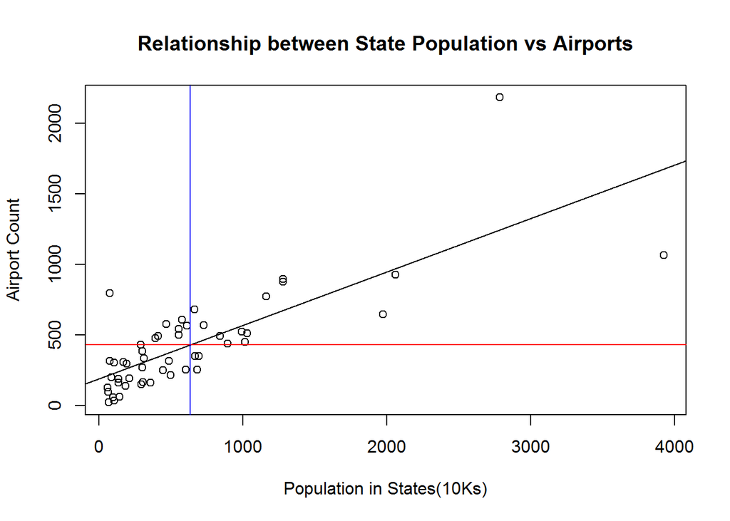

```r
library(ggplot2)
allairports_allpopu_bystat_df.lm1  <- lm(airportcount ~ Popu_10k, data = allairports_allpopu_bystat_df)
plot(allairports_allpopu_bystat_df$airportcount ~ allairports_allpopu_bystat_df$Popu_10k, main = "Relationship between State Population vs Airports",xlab='Population in States(10Ks)',ylab='Airport Count')
abline(allairports_allpopu_bystat_df.lm1 )
abline(h=429,col = "red")
abline(v=633,col = "blue" )
```

### Conclusion….

The above graph suggests that **Airport Count** increases linearly with **Population in States(10Ks)** so I will fit a simple linear regression model to the data model with the **mean** of **Airport Count** and **Population in States(10Ks)**.

```r
summary(allairports_allpopu_bystat_df.lm1)
```

```
##
## Call:
## lm(formula = airportcount ~ Popu_10k, data = allairports_allpopu_bystat_df)
##
## Residuals:
##     Min      1Q  Median      3Q     Max
## -610.92 -122.78  -45.81  115.49  938.51
##
## Coefficients:
##              Estimate Std. Error t value Pr(>|t|)
## (Intercept) 189.87966   42.11856   4.508 4.08e-05 ***
## Popu_10k      0.37886    0.04401   8.608 2.28e-11 ***
## ---
## Signif. codes:  0 '***' 0.001 '**' 0.01 '*' 0.05 '.' 0.1 ' ' 1
##
## Residual standard error: 225.4 on 49 degrees of freedom
## Multiple R-squared:  0.602,  Adjusted R-squared:  0.5938
## F-statistic: 74.11 on 1 and 49 DF,  p-value: 2.277e-11
```

- We get a lot of useful information here without being too overwhelmed by pages of output.
- The estimates for the model intercept is 189.87966 and the coefficient measuring the slope of the relationship with Popu_10k is 0.37886 and information about standard errors of these estimates is also provided in the Coefficients table. We see that the test of significance of the model coefficients is also summarised in that table **so we can see that there is evidence that the coefficient is significantly different to zero - as the population increases so does airports.** It proves Positive Correlation between the number of airports and state population.

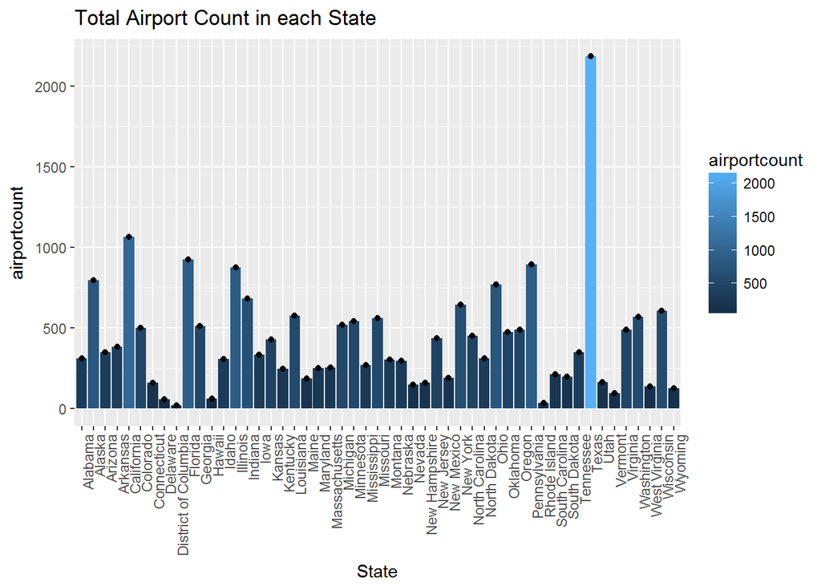

```r
library(ggplot2)
ggplot(allairports_allpopu_bystat_df, aes(fill=airportcount, y=airportcount, x=State)) + ggtitle("Total Airport Count in each State ") +   geom_bar( stat="identity") + theme(axis.text.x = element_text(angle = 90, hjust = 1)) + geom_point()
```

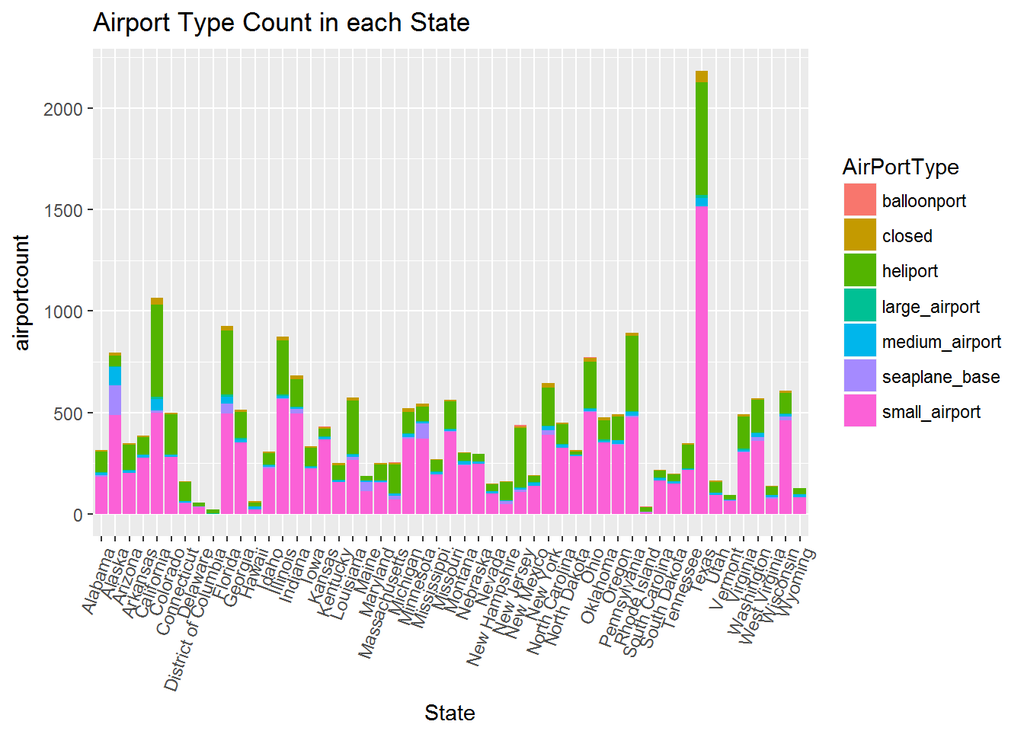

```r
ggplot(allairports_types_allpopu_bystat_df, aes(fill=AirPortType, y=airportcount, x=State)) + ggtitle("Airport Type Count in each State ") + geom_bar( stat="identity") + theme(axis.text.x = element_text(angle = 70, hjust = 1))
```

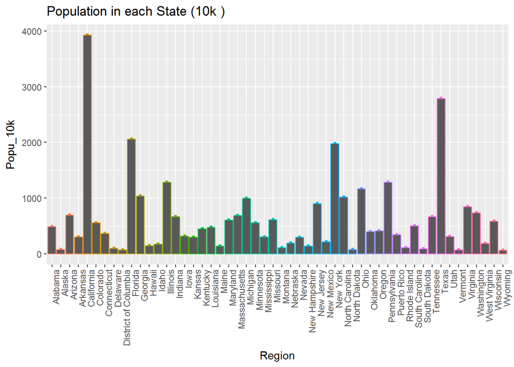

```r
datn1 <- allpopu_bystat_df %>% mutate(Popu_10k = Population / 10000) %>% arrange(Popu_10k)
ggplot(data=datn1, aes(y=Popu_10k,x=Region,  colour=Region)) + theme(axis.text.x = element_text(angle = 90, hjust = 1), legend.position="none") +
 geom_point() +
   geom_bar(stat="identity") +
ggtitle("Population in each State (10k )")
```